# Pre-K Predictors of Kindergarten Math Word Problem Solving

Vishakha Agrawal

2023-05-02

# 1 Introduction

Math knowledge at school entry is one of the strongest predictors of academic achievement (Classens et al., 2009) and low math knowledge at kindergarten entry and exit is associated with high rates of math disability by 5th grade (Morgan et al., 2009). Most studies of risk for math disabilities in very young children (e.g., pre-K and kindergarten) investigate number sense or numbers and operations as outcomes. However, beginning in the elementary grades, math word problems are prevalent on high stakes math testing (Driver & Powell, 2017). Given the importance of math word problem solving, little is known about early math word problem solving and what predicts it; this project examines preschool predictors for word problem solving in kindergarten.

The data used in this project is from a large-scale randomized control trial that followed over 500 students with very low math performance from the beginning of pre-K into kindergarten (original study described in Barnes et al., 2016). Measures of early math skills (e.g., genenal math skills, numeracy), language skills (phonological awareness and word reading) and cognition (e.g., attention, inhibition, visual spatial working memory) were collected at the beginning of pre-K, end of pre-K and end of kindergarten. Additionally, a measure of word problem solving was also collected for 493 students in kindergarten.

## 1.1 Research Question

Given measures of math, language and cognition for pre-K students entering pre-K with very low math scores, how well can we predict whether the student will have low or high word problem solving scores in kindergarten?

# 2 Variables of Interest

Three “types” of measures are available in the dataset - math-related, language-related and cognitive variables. Variables are named to reflect the construct/measure and time point (preK or K). More information on the measures can be found in Barnes et al. (2016; 2020).

## 2.1 Math-related predictor

Test of Early Math Ability, 3rd edition (TEMA) is a standardized assessment of early math skills. This project uses the scaled TEMA score from the beginning of pre-K (math_preK).

## 2.2 Language-related predictors

Phonological awareness was assessed in English or Spanish using the TOPEL or SPELA, respectively. Scaled scores for each student were transformed into z-scores for the entire sample at the beginning of pre-K (PA_preK).

Word reading was assessed in English or Spanish using the Letter Word ID subtest of the Woodcock Johnson III or the Identificación de letras y palabras from the Batería III Woodcock-Muñoz, respectively. Scaled scores for each student are used in this project (LWID_preK).

## 2.3 Cognitive predictors

The dataset includes measures of visual-spatial working memory (VSWM_preK), nonverbal IQ (iq_preK), Approximate number sense (ANS) acuity and attention all collected at the beginning of pre-K.

VSWM was assessed using a task similar to a standard Corsi-Blocks task. VSWM_preK is a raw score, ranging from 0-8.

Nonverbal IQ was tested using the matrices subtest of the Kaufman Brief Intelligence Test, 2nd edition (KBIT-2). The KBIT-2 is a standardized assessment and iq_preK are scaled scores.

ANS acuity refers to an individual’s ability to perceive and discriminate differences in quantity without counting. Research has shown that deficits in ANS acuity can help distinguish between students at-risk for math disability and those not at risk. Here, ANS acuity was measured using Panamath, a computerized task, with congruent (ANS_cong_preK) and incongruent (ANS_inco_preK) trials. Accuracy (proportion correct) on each type of trial is used for analyses.

Attention is often used as an umbrella term for sustained attention, inhibitory control, and impulsivity. Tasks that measure attention usually tap into one of these constructs and can be either direct assessments (e.g., flanker task) or questionnaires filled out by teachers or caregivers (e.g., Child Behavior Questionnaire). The dataset contains three assessments of attention - Computerized flanker task (Child-ANT), computerized continuous performance task (CPT) and the teacher version of the Child Behavior Questionnaire (CBQ).

Accuracy scores on congruent and incongruent trials of a computerized flanker task (Child-ANT), respectively, are measures of sustained attention and inhibition. Theoretically, ChANT_att_wv1 and ChANT_inhib_wv1 can range from 0-1.

Two types of errors are possible in a CPT - omission and comission errors. Omission errors occur when a participant misses a trial with a target stimulus, which indicates a loss in sustained attention (CPT_att_preK). Comission errors occur when a participant responds to a trial without a target stimulus, indicating a deficit in impulse or inhibitory control (CPT_inhib_preK). As expected, CPT scores are inversely proportional to a participant’s sustained attention and inhibitory control skills. For this project, a raw score of number of omission and comission errors is used.

The Child Behavior Questionnaire (CBQ) has subscales for sustained attention (CBQ_att_preK), inhibitory control (CBQ_inhib_preK) and impulsivity (CBQ_impul_preK). Higher scores indicate better sustained attention and inhibitory control and greater impulsivity.

## 2.4 Outcome of interest

The primary outcome of interest is math word problem solving (WPS). This was collected as an add-on subtest to the Child Math Assessment and is only available for the kindergarten time point. Students were asked 3 addition and 3 subtraction word problems and scored 1 if they answered correctly and 0 if incorrect, for a maximum score of 6. In this dataset, scores range from 0-6 but are not normally distributed. Consequently, logistic regression is used instead of linear regression.

# 3 Analysis plan

First, a principal component analysis (PCA) will be conducted for dimensionality reduction. Then, a logistic regression will be used to answer the primary research question.

# 4 Principal Component Analysis

## 4.1 Call-in data and clean-up tibble

```r
library(tidyverse) #load tidyverse package
```

```r
library(ggplot2) #load ggplot package
library(psych) #load psych package
#options(scipen=999)

#Calling in csv file to create a pruned tibble with kindergarten math word problem solving scores and other preschool and kindergarten measures of math, language & cognitive variables.
wps_predictors <- read_csv("va_dataset.csv", show_col_types = FALSE) %>%
  select("VSWMCTR_wv1", "acc_wo_0_cong_wv1", "acc_wo_0_inco_wv1", "kbit_SS_wv1", "tem3_SS_wv1", "CPT_Omit_w1", "CPT_Commit_w1", "PRC_PanaCong_1", "PRC_PanaIncong_1", "CBQAttention1", "CBQInhibit1", "CBQImpulsivity1", "PhonologicalAwareness_wv1", "LWID_ss_wv2_eng_or_span", "CMA_WPS_wv3") %>%
  filter(CMA_WPS_wv3 == 0 | CMA_WPS_wv3 == 1 | CMA_WPS_wv3 == 2 | CMA_WPS_wv3 == 3 | CMA_WPS_wv3 == 4 | CMA_WPS_wv3 == 5 | CMA_WPS_wv3 == 6)  %>%  #remove rows with outcome variable not from 0-6
  rename("VSWM_preK" = "VSWMCTR_wv1", "ChANT_att_preK" = "acc_wo_0_cong_wv1", "ChANT_inhib_preK" = "acc_wo_0_inco_wv1", "iq_preK" = "kbit_SS_wv1", "math_preK" = "tem3_SS_wv1", "CPT_att_preK" = "CPT_Omit_w1", "CPT_inhib_preK" = "CPT_Commit_w1", "ANS_cong_preK" = "PRC_PanaCong_1", "ANS_inco_preK" = "PRC_PanaIncong_1", "CBQ_att_preK" = "CBQAttention1", "CBQ_inhib_preK" = "CBQInhibit1", "CBQ_impul_preK" = "CBQImpulsivity1", "PA_preK" = "PhonologicalAwareness_wv1", "LWID_preK" = "LWID_ss_wv2_eng_or_span", "WPS_K" = "CMA_WPS_wv3") %>% #changing variable names to meaningful names
  relocate(WPS_K, math_preK, PA_preK, LWID_preK, VSWM_preK, iq_preK, ChANT_att_preK, ChANT_inhib_preK, CBQ_att_preK, CBQ_inhib_preK, CBQ_impul_preK, CPT_att_preK, CPT_inhib_preK, ANS_cong_preK, ANS_inco_preK, ) %>% #reorder columns to make more sense
  na.omit() #omit all NAs
str(wps_predictors) #checking the structure of the tibble
```

```
## tibble [469 × 15] (S3: tbl_df/tbl/data.frame)
##  $ WPS_K           : num [1:469] 1 4 6 4 6 0 5 4 4 3 ...
##  $ math_preK       : num [1:469] 82 75 70 68 89 92 65 72 70 65 ...
##  $ PA_preK         : num [1:469] 1.38 0.876 2.39 -0.638 -0.386 ...
##  $ LWID_preK       : num [1:469] 84 105 105 100 100 105 83 89 103 88 ...
##  $ VSWM_preK       : num [1:469] 6 6 4 0 4 4 3 4 6 0 ...
##  $ iq_preK         : num [1:469] 107 95 98 55 90 99 81 94 74 74 ...
##  $ ChANT_att_preK  : num [1:469] 0.971 0.97 0.909 0.667 0.967 ...
##  $ ChANT_inhib_preK: num [1:469] 0.812 0.97 0.156 0.455 0.75 ...
##  $ CBQ_att_preK    : num [1:469] 4.57 4.93 3.71 2.14 5.79 ...
##  $ CBQ_inhib_preK  : num [1:469] 4.92 5.62 4.38 3.46 6.08 ...
##  $ CBQ_impul_preK  : num [1:469] 3.69 2.85 4.23 4.15 2.85 ...
##  $ CPT_att_preK    : num [1:469] 3 2 13 22 3 19 4 4 9 15 ...
##  $ CPT_inhib_preK  : num [1:469] 3 10 24 3 1 42 10 2 2 2 ...
##  $ ANS_cong_preK   : num [1:469] 1 0.632 0.842 0.9 1 ...
##  $ ANS_inco_preK   : num [1:469] 1 0.667 0.667 0.55 0.95 ...
##  - attr(*, "na.action")= 'omit' Named int [1:24] 6 7 11 20 44 65 66 69 73 89 ...
##   ..- attr(*, "names")= chr [1:24] "6" "7" "11" "20" ...
```

```r
#write.csv(wps_predictors, "wps_predictors.csv") #write file with pruned tibble for easy call-in
```

## 4.2 Variable distributions and Multicollinearity

Before conducting a PCA, variables need to be checked for normality and multicollinearity.

[output not shown]

[output cut: 126 more lines]

[output not shown]

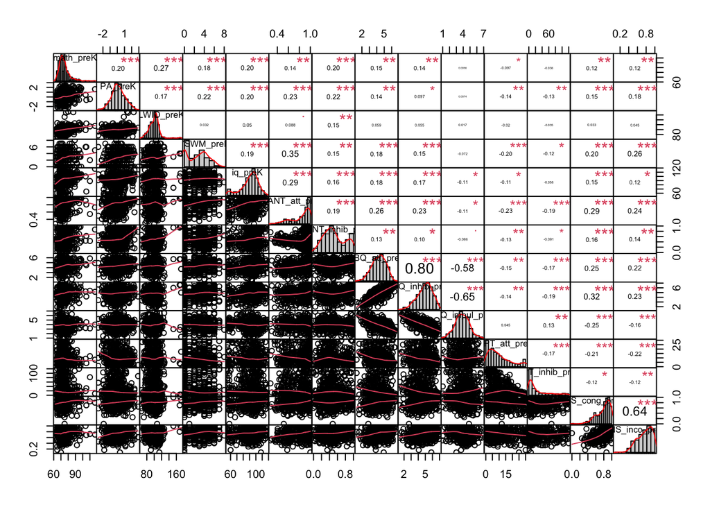

```r
pca_tib <- wps_predictors[,2:15] #remove WPS column as it is the outcome of interest

#install.packages("PerformanceAnalytics")
library(PerformanceAnalytics) #for chart.Correlation
chart.Correlation(pca_tib, histogram = TRUE, method = "pearson") #visualize variable distributions, correlations and homogeneity of variance
```

**Some variables are not normally distributed so they need to be removed before conducting PCA.**

[output not shown]

[output cut: 16 more lines]

[output not shown]

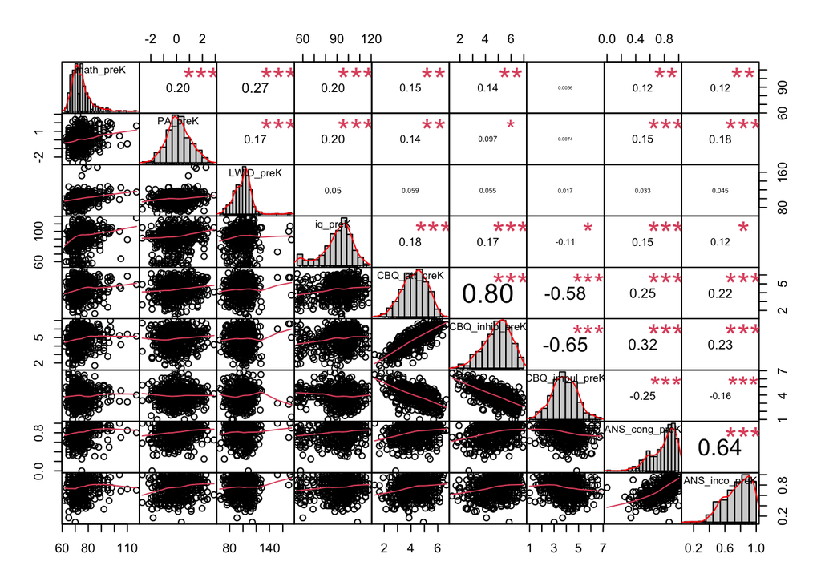

```r
pca_data <- pca_tib %>%
  select(-VSWM_preK) %>% #very problematic
  select(-ChANT_att_preK) %>% #very problematic
  select(-CPT_inhib_preK) %>% #very problematic
  select(-ChANT_inhib_preK) %>% #problematic but maybe not enough to warrant removal??
  select(-CPT_att_preK) #problematic but maybe not enough to warrant removal??


chart.Correlation(pca_data, histogram = TRUE, method = "pearson") #Recheck plots of variables
```

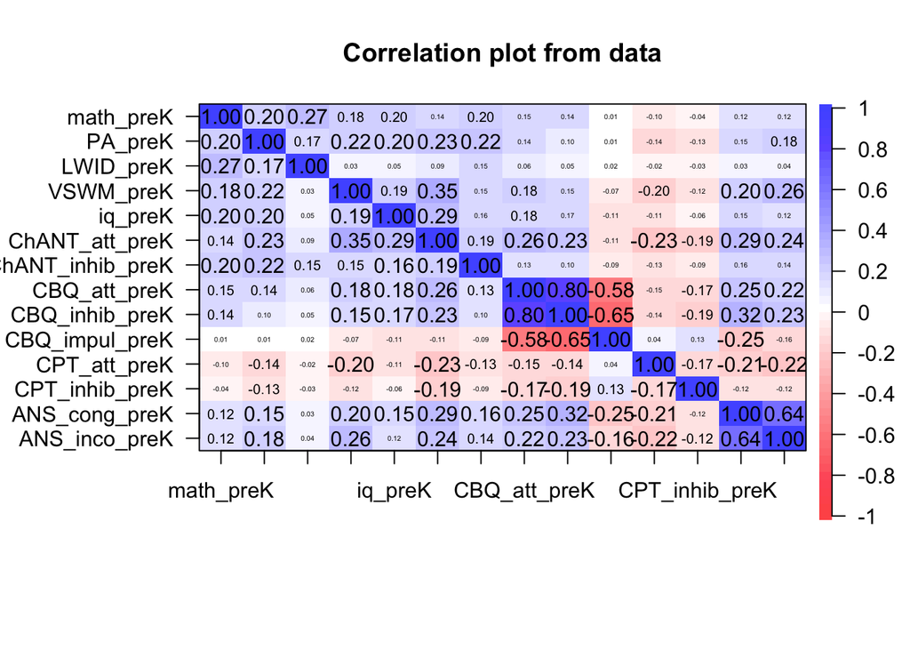

```r
cor.plot(pca_tib) #visualize correlation strength for multicollinearity
```

**The scores for the attention and inhibition sub-scales from the Child Behavior Questionnaire (CBQ) are highly correlated (r ~ 0.80) but not high enough to remove due to multicollinearity.**

## 4.3 Scaling variables

Before conducting a PCA, variables are scaled so that their factor loadings are not affected by the different scales of the variables.

```r
scaled_pca_data <- pca_data %>%
  mutate_at(c(1:9), ~(scale(.) %>% as.vector))

str(scaled_pca_data)
```

```
## tibble [469 × 9] (S3: tbl_df/tbl/data.frame)
##  $ math_preK     : num [1:469] 1.0514 0.0758 -0.6211 -0.8998 2.027 ...
##  $ PA_preK       : num [1:469] 1.384 0.864 2.424 -0.697 -0.437 ...
##  $ LWID_preK     : num [1:469] -1.245 0.375 0.375 -0.0107 -0.0107 ...
##  $ iq_preK       : num [1:469] 1.118 0.239 0.458 -2.692 -0.128 ...
##  $ CBQ_att_preK  : num [1:469] 0.224 0.578 -0.624 -2.179 1.426 ...
##  $ CBQ_inhib_preK: num [1:469] 0.11 0.733 -0.375 -1.206 1.148 ...
##  $ CBQ_impul_preK: num [1:469] -0.21 -1.026 0.31 0.236 -1.026 ...
##  $ ANS_cong_preK : num [1:469] 1.204 -0.955 0.279 0.618 1.204 ...
##  $ ANS_inco_preK : num [1:469] 1.382 -0.451 -0.451 -1.092 1.107 ...
##  - attr(*, "na.action")= 'omit' Named int [1:24] 6 7 11 20 44 65 66 69 73 89 ...
##   ..- attr(*, "names")= chr [1:24] "6" "7" "11" "20" ...
```

```r
psych::describe(scaled_pca_data) #descriptives to check if scaling worked
```

```
##                vars   n mean sd median trimmed  mad   min  max range  skew
## math_preK         1 469    0  1  -0.20   -0.13 0.62 -1.74 5.93  7.67  1.72
## PA_preK           2 469    0  1  -0.18   -0.01 0.90 -2.78 2.94  5.72  0.14
## LWID_preK         3 469    0  1   0.14    0.01 0.91 -2.71 5.62  8.33  0.79
## iq_preK           4 469    0  1   0.17    0.10 0.76 -2.69 1.92  4.62 -0.88
## CBQ_att_preK      5 469    0  1   0.08    0.03 1.05 -3.03 2.27  5.30 -0.27
## CBQ_inhib_preK    6 469    0  1   0.11    0.05 1.03 -3.08 1.98  5.06 -0.45
## CBQ_impul_preK    7 469    0  1   0.01    0.01 0.99 -2.81 2.83  5.64 -0.01
## ANS_cong_preK     8 469    0  1   0.33    0.10 0.87 -4.66 1.20  5.86 -0.97
## ANS_inco_preK     9 469    0  1   0.22    0.06 1.00 -3.66 1.38  5.04 -0.56
##                kurtosis   se
## math_preK          5.02 0.05
## PA_preK           -0.17 0.05
## LWID_preK          5.06 0.05
## iq_preK            0.51 0.05
## CBQ_att_preK      -0.44 0.05
## CBQ_inhib_preK    -0.23 0.05
## CBQ_impul_preK    -0.08 0.05
## ANS_cong_preK      0.64 0.05
## ANS_inco_preK     -0.38 0.05
```

**All variables now have a mean of 0 and standard deviation of 1.**

## 4.4 Round 1/Base PCA

### 4.4.1 Visualize components

```r
library(factoextra) #extract and visualize the output of multivariate data analyses, including 'PCA'
```

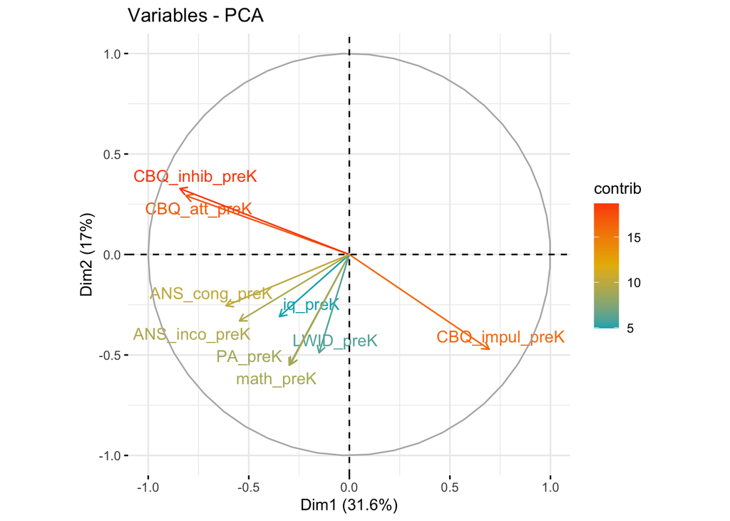

```r
#line below runs a simple PCA with a component for each variable.
#the most variance will be explained in component 1 and 2
viz_pca <- prcomp(scaled_pca_data, center = TRUE,scale. = TRUE)


#Graph of variables. Positive correlated variables point to the same side of the plot. Negative correlated variables point to opposite sides of the graph.

fviz_pca_var(viz_pca,
             col.var = "contrib", # Color by contributions to the PC
             gradient.cols = c("#00AFBB", "#E7B800", "#FC4E07"),
             repel = TRUE #Avoid overlapping text if possible
             )
```

**From the visualization, it looks like the following are loading together:**

1. CBQ subscales
2. ANS acuity scores
3. Academic subtests

### 4.4.2 Bartlett’s test

```r
cortest.bartlett(scaled_pca_data, 469)
```

```
## R was not square, finding R from data
```

```
## $chisq
## [1] 1185.508
##
## $p.value
## [1] 1.481328e-225
##
## $df
## [1] 36
```

**Since p<.05, the R-matrix is not an identity matrix and we can do PCA with the included predictors.**

### 4.4.3 Measure of Sampling Adequacy - Kaiser-Meyer-Olkin index

The test measures sampling adequacy for each variable in the model and for the complete model. The Kaiser-Meyer-Olkin (KMO) index is a measure of the proportion of variance among variables that might be common variance. The higher the proportion, the more suited your data is to Factor Analysis. The recommended threshold for KMO is 0.5.

```r
KMO(scaled_pca_data) #Check that all are at least >0.5
```

```
## Kaiser-Meyer-Olkin factor adequacy
## Call: KMO(r = scaled_pca_data)
## Overall MSA =  0.69
## MSA for each item =
##      math_preK        PA_preK      LWID_preK        iq_preK   CBQ_att_preK
##           0.67           0.73           0.61           0.79           0.71
## CBQ_inhib_preK CBQ_impul_preK  ANS_cong_preK  ANS_inco_preK
##           0.68           0.82           0.63           0.61
```

**KMO values range from 0.61-0.82 with overall MSA = 0.69 which is acceptable for conducting a PCA.**

### 4.4.4 Base PCA

The eigenvalues associated with each factor represent the variance explained by that particular linear component. R calls these SS loadings (sums of squared loadings), because they are the sum of the squared loadings. The number of SS loadings greater than 1 (Kaiser’s criterion) determines the number of potential components.

```r
#run a base pca with as many components as possible - 9 variables

pca_base <- principal(scaled_pca_data, nfactors = 9, rotate = "none")

pca_base #results of base PCA
```

```
## Principal Components Analysis
## Call: principal(r = scaled_pca_data, nfactors = 9, rotate = "none")
## Standardized loadings (pattern matrix) based upon correlation matrix
##                  PC1   PC2   PC3   PC4   PC5   PC6   PC7   PC8   PC9 h2
## math_preK       0.30  0.55  0.37 -0.12  0.41 -0.53 -0.11 -0.02 -0.01  1
## PA_preK         0.29  0.55  0.14  0.24 -0.72 -0.14 -0.09  0.01  0.01  1
## LWID_preK       0.15  0.49  0.44 -0.55  0.00  0.50  0.02  0.00  0.00  1
## iq_preK         0.35  0.31  0.18  0.73  0.31  0.34  0.03 -0.02  0.01  1
## CBQ_att_preK    0.81 -0.29  0.24 -0.02 -0.08 -0.08  0.32  0.01 -0.28  1
## CBQ_inhib_preK  0.84 -0.33  0.19 -0.05 -0.03 -0.05  0.16  0.08  0.33  1
## CBQ_impul_preK -0.70  0.47 -0.11  0.03  0.01 -0.10  0.49  0.15  0.06  1
## ANS_cong_preK   0.61  0.25 -0.60 -0.09  0.09  0.06 -0.11  0.40 -0.05  1
## ANS_inco_preK   0.55  0.33 -0.64 -0.13  0.04  0.02  0.12 -0.39  0.03  1
##                      u2 com
## math_preK       1.1e-16 4.5
## PA_preK         1.0e-15 2.8
## LWID_preK       1.1e-16 4.1
## iq_preK         4.4e-16 3.0
## CBQ_att_preK   -2.2e-16 2.2
## CBQ_inhib_preK -2.2e-16 1.9
## CBQ_impul_preK -8.9e-16 2.9
## ANS_cong_preK  -4.4e-16 3.3
## ANS_inco_preK  -2.2e-16 3.5
##
##                        PC1  PC2  PC3  PC4  PC5  PC6  PC7  PC8  PC9
## SS loadings           2.85 1.53 1.25 0.94 0.79 0.68 0.42 0.35 0.19
## Proportion Var        0.32 0.17 0.14 0.10 0.09 0.08 0.05 0.04 0.02
## Cumulative Var        0.32 0.49 0.63 0.73 0.82 0.89 0.94 0.98 1.00
## Proportion Explained  0.32 0.17 0.14 0.10 0.09 0.08 0.05 0.04 0.02
## Cumulative Proportion 0.32 0.49 0.63 0.73 0.82 0.89 0.94 0.98 1.00
##
## Mean item complexity =  3.1
## Test of the hypothesis that 9 components are sufficient.
##
## The root mean square of the residuals (RMSR) is  0
##  with the empirical chi square  0  with prob <  NA
##
## Fit based upon off diagonal values = 1
```

**Based on SS loadings (>1), we have 3 potential components.**

The Scree plot shows the eigenvalues (y) against the factor number (x). Change in inflection of the plot indicates how many components should be estimated.

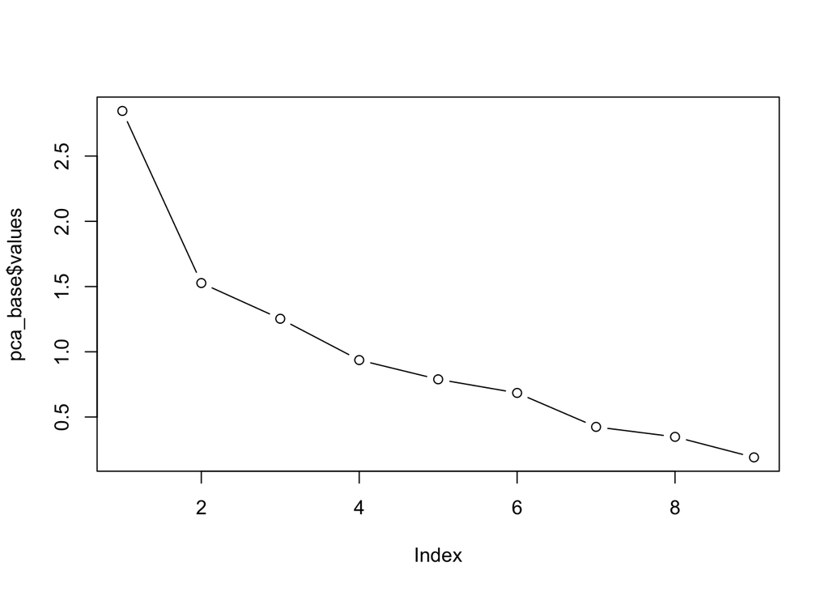

```r
#scree plot using eigen values stored in pca_1$values
plot(pca_base$values, type = "b")
```

**Inflection is very slight but visible - 3 components shouls be estimated.***

### 4.4.5 Check for normally distributed residuals before conducting informed PCA

```r
pca_resid <- principal(scaled_pca_data, nfactors = 3, rotate = "none")
pca_resid #results
```

```
## Principal Components Analysis
## Call: principal(r = scaled_pca_data, nfactors = 3, rotate = "none")
## Standardized loadings (pattern matrix) based upon correlation matrix
##                  PC1   PC2   PC3   h2   u2 com
## math_preK       0.30  0.55  0.37 0.53 0.47 2.4
## PA_preK         0.29  0.55  0.14 0.40 0.60 1.7
## LWID_preK       0.15  0.49  0.44 0.45 0.55 2.2
## iq_preK         0.35  0.31  0.18 0.25 0.75 2.5
## CBQ_att_preK    0.81 -0.29  0.24 0.81 0.19 1.5
## CBQ_inhib_preK  0.84 -0.33  0.19 0.85 0.15 1.4
## CBQ_impul_preK -0.70  0.47 -0.11 0.72 0.28 1.8
## ANS_cong_preK   0.61  0.25 -0.60 0.80 0.20 2.3
## ANS_inco_preK   0.55  0.33 -0.64 0.81 0.19 2.5
##
##                        PC1  PC2  PC3
## SS loadings           2.85 1.53 1.25
## Proportion Var        0.32 0.17 0.14
## Cumulative Var        0.32 0.49 0.63
## Proportion Explained  0.51 0.27 0.22
## Cumulative Proportion 0.51 0.78 1.00
##
## Mean item complexity =  2
## Test of the hypothesis that 3 components are sufficient.
##
## The root mean square of the residuals (RMSR) is  0.1
##  with the empirical chi square  305.51  with prob <  3.3e-58
##
## Fit based upon off diagonal values = 0.88
```

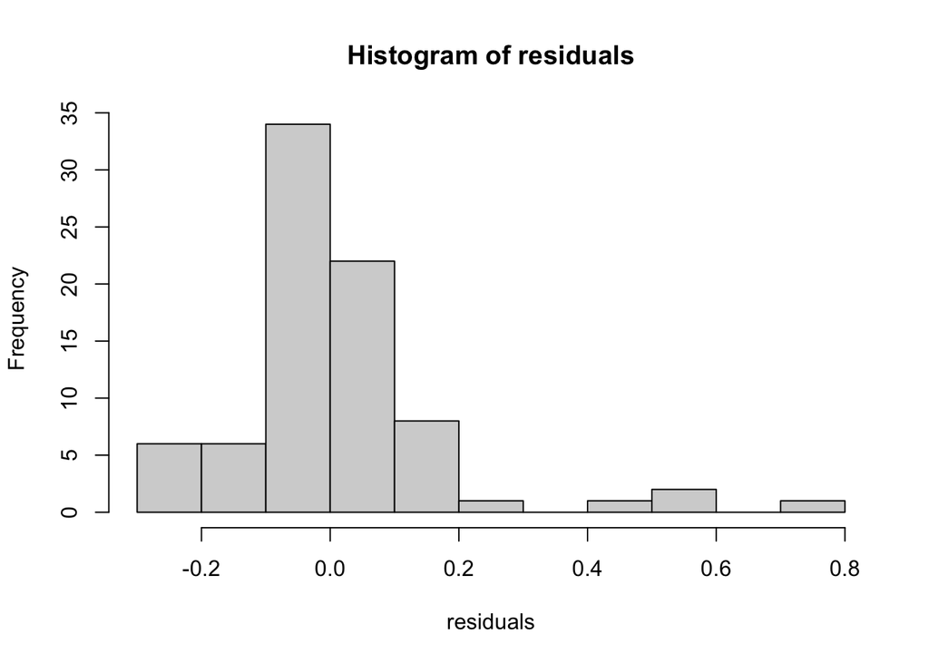

```r
#residuals
#require correlation matrix for final data
corMatrix<-cor(scaled_pca_data)
#corMatrix

#next,create an object from the correlation matrix and the pca loading. Call it residuals. It will contain the factor residuals
residuals<-factor.residuals(corMatrix, pca_resid$loadings)

#call a histogram to check residuals
hist(residuals)
```

**Residuals are mostly normally distributed with a right tail, but that’s okay.**

## 4.5 Informed PCA with oblique rotation

Now that we have determined that the PCA should estimate 3 components, we choose an oblique rotation because our factors are assumed to be related and not independent.

```r
#Since factors should be related, use oblique technique (promax).
pca_final <- principal(scaled_pca_data, nfactors = 3, rotate = "promax")
pca_final #results.
```

```
## Principal Components Analysis
## Call: principal(r = scaled_pca_data, nfactors = 3, rotate = "promax")
## Standardized loadings (pattern matrix) based upon correlation matrix
##                  RC1   RC3   RC2   h2   u2 com
## math_preK       0.03 -0.03  0.73 0.53 0.47 1.0
## PA_preK        -0.07  0.18  0.58 0.40 0.60 1.2
## LWID_preK      -0.02 -0.17  0.69 0.45 0.55 1.1
## iq_preK         0.14  0.08  0.43 0.25 0.75 1.3
## CBQ_att_preK    0.89 -0.02  0.09 0.81 0.19 1.0
## CBQ_inhib_preK  0.91  0.02  0.04 0.85 0.15 1.0
## CBQ_impul_preK -0.86  0.01  0.16 0.72 0.28 1.1
## ANS_cong_preK   0.06  0.88 -0.04 0.80 0.20 1.0
## ANS_inco_preK  -0.05  0.92 -0.02 0.81 0.19 1.0
##
##                        RC1  RC3  RC2
## SS loadings           2.38 1.69 1.56
## Proportion Var        0.26 0.19 0.17
## Cumulative Var        0.26 0.45 0.63
## Proportion Explained  0.42 0.30 0.28
## Cumulative Proportion 0.42 0.72 1.00
##
##  With component correlations of
##      RC1  RC3  RC2
## RC1 1.00 0.30 0.14
## RC3 0.30 1.00 0.22
## RC2 0.14 0.22 1.00
##
## Mean item complexity =  1.1
## Test of the hypothesis that 3 components are sufficient.
##
## The root mean square of the residuals (RMSR) is  0.1
##  with the empirical chi square  305.51  with prob <  3.3e-58
##
## Fit based upon off diagonal values = 0.88
```

```r
#let's make the results easier to read. Include loadings over .3 (think of medium correlation) and sort them

print.psych(pca_final, cut = 0.3, sort = TRUE)
```

```
## Principal Components Analysis
## Call: principal(r = scaled_pca_data, nfactors = 3, rotate = "promax")
## Standardized loadings (pattern matrix) based upon correlation matrix
##                item   RC1   RC3   RC2   h2   u2 com
## CBQ_inhib_preK    6  0.91             0.85 0.15 1.0
## CBQ_att_preK      5  0.89             0.81 0.19 1.0
## CBQ_impul_preK    7 -0.86             0.72 0.28 1.1
## ANS_inco_preK     9        0.92       0.81 0.19 1.0
## ANS_cong_preK     8        0.88       0.80 0.20 1.0
## math_preK         1              0.73 0.53 0.47 1.0
## LWID_preK         3              0.69 0.45 0.55 1.1
## PA_preK           2              0.58 0.40 0.60 1.2
## iq_preK           4              0.43 0.25 0.75 1.3
##
##                        RC1  RC3  RC2
## SS loadings           2.38 1.69 1.56
## Proportion Var        0.26 0.19 0.17
## Cumulative Var        0.26 0.45 0.63
## Proportion Explained  0.42 0.30 0.28
## Cumulative Proportion 0.42 0.72 1.00
##
##  With component correlations of
##      RC1  RC3  RC2
## RC1 1.00 0.30 0.14
## RC3 0.30 1.00 0.22
## RC2 0.14 0.22 1.00
##
## Mean item complexity =  1.1
## Test of the hypothesis that 3 components are sufficient.
##
## The root mean square of the residuals (RMSR) is  0.1
##  with the empirical chi square  305.51  with prob <  3.3e-58
##
## Fit based upon off diagonal values = 0.88
```

### 4.5.1 Plot out results from informed PCA

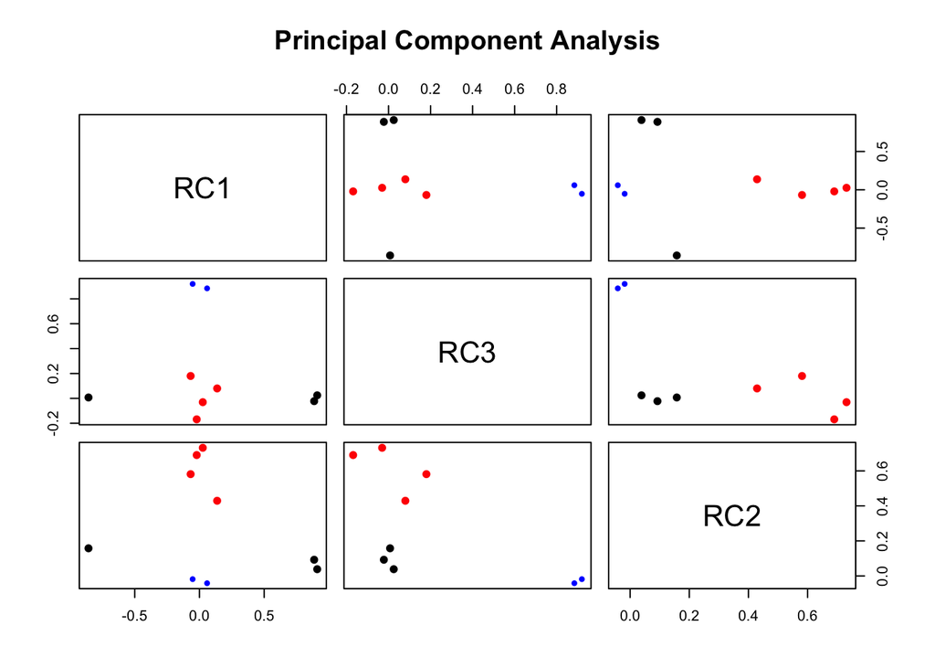

```r
plot(pca_final)
```

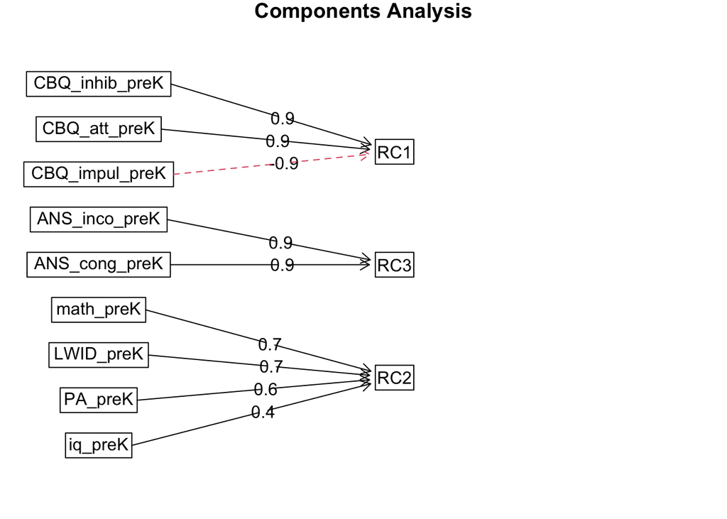

```r
#The far right on each box shows where the component's observations cluster compared to each other cluster
#component 1 is black
#component 2 is blue
#component 3 is red

#looking for separation among the components

fa.diagram(pca_final)
```

**Separation among components looks good and the loadings of different variables on to factors also seems theoretically sound.**

**The Most Important Task is Naming the Components!!!**

**Component 1: Child Behavior Questionnaire Composite, with the all variables loading equally strongly (note that the direction of the loading of CBQ_impul_preK is opposite to other CBQ scales and this is expected)**

**Component 2: Academic skill + IQ (Can be academic & cognitive ability), with math_preK and LWID_preK loading strongest**

**Component 3: ANS Acuity, with equally stong loading of both congruent and incongruent trials**

## 4.6 Collect factor scores

To be able to use the components from the PCA in the logistic regresion analysis, we need to add the factor scores to the tibble with the orginial data.

```r
#we need the pca scores
pca_final_scores <- as.data.frame(pca_final$scores) #scores for each text on each factor. You can use these in subsequent analyses. Lot's of them though

#rename columns
pca_final_scores <- pca_final_scores %>%
  rename(CBQ_composite = RC1, Academic_Cognitive_skill = RC2, ANS_acuity = RC3)

#combine this dataframe with earlier dataframe (wps_predictors)

str(wps_predictors)
```

```
## tibble [469 × 15] (S3: tbl_df/tbl/data.frame)
##  $ WPS_K           : num [1:469] 1 4 6 4 6 0 5 4 4 3 ...
##  $ math_preK       : num [1:469] 82 75 70 68 89 92 65 72 70 65 ...
##  $ PA_preK         : num [1:469] 1.38 0.876 2.39 -0.638 -0.386 ...
##  $ LWID_preK       : num [1:469] 84 105 105 100 100 105 83 89 103 88 ...
##  $ VSWM_preK       : num [1:469] 6 6 4 0 4 4 3 4 6 0 ...
##  $ iq_preK         : num [1:469] 107 95 98 55 90 99 81 94 74 74 ...
##  $ ChANT_att_preK  : num [1:469] 0.971 0.97 0.909 0.667 0.967 ...
##  $ ChANT_inhib_preK: num [1:469] 0.812 0.97 0.156 0.455 0.75 ...
##  $ CBQ_att_preK    : num [1:469] 4.57 4.93 3.71 2.14 5.79 ...
##  $ CBQ_inhib_preK  : num [1:469] 4.92 5.62 4.38 3.46 6.08 ...
##  $ CBQ_impul_preK  : num [1:469] 3.69 2.85 4.23 4.15 2.85 ...
##  $ CPT_att_preK    : num [1:469] 3 2 13 22 3 19 4 4 9 15 ...
##  $ CPT_inhib_preK  : num [1:469] 3 10 24 3 1 42 10 2 2 2 ...
##  $ ANS_cong_preK   : num [1:469] 1 0.632 0.842 0.9 1 ...
##  $ ANS_inco_preK   : num [1:469] 1 0.667 0.667 0.55 0.95 ...
##  - attr(*, "na.action")= 'omit' Named int [1:24] 6 7 11 20 44 65 66 69 73 89 ...
##   ..- attr(*, "names")= chr [1:24] "6" "7" "11" "20" ...
```

```r
final_data <- cbind(wps_predictors, pca_final_scores)
str(final_data)
```

```
## 'data.frame':    469 obs. of  18 variables:
##  $ WPS_K                   : num  1 4 6 4 6 0 5 4 4 3 ...
##  $ math_preK               : num  82 75 70 68 89 92 65 72 70 65 ...
##  $ PA_preK                 : num  1.38 0.876 2.39 -0.638 -0.386 ...
##  $ LWID_preK               : num  84 105 105 100 100 105 83 89 103 88 ...
##  $ VSWM_preK               : num  6 6 4 0 4 4 3 4 6 0 ...
##  $ iq_preK                 : num  107 95 98 55 90 99 81 94 74 74 ...
##  $ ChANT_att_preK          : num  0.971 0.97 0.909 0.667 0.967 ...
##  $ ChANT_inhib_preK        : num  0.812 0.97 0.156 0.455 0.75 ...
##  $ CBQ_att_preK            : num  4.57 4.93 3.71 2.14 5.79 ...
##  $ CBQ_inhib_preK          : num  4.92 5.62 4.38 3.46 6.08 ...
##  $ CBQ_impul_preK          : num  3.69 2.85 4.23 4.15 2.85 ...
##  $ CPT_att_preK            : num  3 2 13 22 3 19 4 4 9 15 ...
##  $ CPT_inhib_preK          : num  3 10 24 3 1 42 10 2 2 2 ...
##  $ ANS_cong_preK           : num  1 0.632 0.842 0.9 1 ...
##  $ ANS_inco_preK           : num  1 0.667 0.667 0.55 0.95 ...
##  $ CBQ_composite           : num  0.245 0.838 -0.525 -1.46 1.371 ...
##  $ ANS_acuity              : num  1.702 -0.663 0.186 -0.489 1.155 ...
##  $ Academic_Cognitive_skill: num  0.764 0.54 0.888 -1.568 0.743 ...
```

```r
#write.csv(pca_final_scores,"pca_scores_final_df.csv", row.names=FALSE)
```

# 5 Logistic Regression Model

For logistic regression, the outcome variable needs to be a factor with two levels. Since WPS is a continuous variable that needs to be converted into a binomial factor, I will use a median split to create a new outcome variable with levels high and low.

```r
#create a tibble with just the WPS score outcome and predictors (PCA components + predictors not included in PCA analysis)
final_data <- final_data %>%
  select(WPS_K, CBQ_composite, Academic_Cognitive_skill, ANS_acuity, VSWM_preK, ChANT_att_preK, ChANT_inhib_preK) %>%
  na.omit()

final_data <- final_data %>%
  mutate(WPS_mediansplit = case_when(WPS_K < 5 ~ "Low", WPS_K > 4 ~ "High"))

final_data$WPS_mediansplit <- as.factor(final_data$WPS_mediansplit) #create a new factor variable based on the median split for WPS scores to be the outcome for the logistic regression

str(final_data) #check tibble structure
```

```
## 'data.frame':    469 obs. of  8 variables:
##  $ WPS_K                   : num  1 4 6 4 6 0 5 4 4 3 ...
##  $ CBQ_composite           : num  0.245 0.838 -0.525 -1.46 1.371 ...
##  $ Academic_Cognitive_skill: num  0.764 0.54 0.888 -1.568 0.743 ...
##  $ ANS_acuity              : num  1.702 -0.663 0.186 -0.489 1.155 ...
##  $ VSWM_preK               : num  6 6 4 0 4 4 3 4 6 0 ...
##  $ ChANT_att_preK          : num  0.971 0.97 0.909 0.667 0.967 ...
##  $ ChANT_inhib_preK        : num  0.812 0.97 0.156 0.455 0.75 ...
##  $ WPS_mediansplit         : Factor w/ 2 levels "High","Low": 2 2 1 2 1 2 1 2 2 2 ...
```

Next, the groups based on the outcome must be balanced for logistic regression to be accurate.

```r
table(final_data$WPS_mediansplit) #check if groups are balanced
```

```
##
## High  Low
##  205  264
```

```r
final_data_2 <- final_data %>%
  group_by(WPS_mediansplit) %>%
  sample_n(205) %>% #equalize groups by selecting 205 observations per group
  select(-WPS_K) #remove the original WPS scores from the tibble

str(final_data_2)
```

```
## gropd_df [410 × 7] (S3: grouped_df/tbl_df/tbl/data.frame)
##  $ CBQ_composite           : num [1:410] -1.347 -0.189 1.208 -0.435 -1.014 ...
##  $ Academic_Cognitive_skill: num [1:410] 0.608 -0.517 1.146 0.154 0.121 ...
##  $ ANS_acuity              : num [1:410] 1.14 -1.87 1.69 -1.28 -1.37 ...
##  $ VSWM_preK               : num [1:410] 5 0 5 0 4 3 2 0 4 4 ...
##  $ ChANT_att_preK          : num [1:410] 0.938 0.848 1 0.6 0.846 ...
##  $ ChANT_inhib_preK        : num [1:410] 0.394 0.182 1 0.5 0.808 ...
##  $ WPS_mediansplit         : Factor w/ 2 levels "High","Low": 1 1 1 1 1 1 1 1 1 1 ...
##  - attr(*, "groups")= tibble [2 × 2] (S3: tbl_df/tbl/data.frame)
##   ..$ WPS_mediansplit: Factor w/ 2 levels "High","Low": 1 2
##   ..$ .rows          : list<int> [1:2]
##   .. ..$ : int [1:205] 1 2 3 4 5 6 7 8 9 10 ...
##   .. ..$ : int [1:205] 206 207 208 209 210 211 212 213 214 215 ...
##   .. ..@ ptype: int(0)
##   ..- attr(*, ".drop")= logi TRUE
```

```r
table(final_data_2$WPS_mediansplit) #confirm that groups are balanced
```

```
##
## High  Low
##  205  205
```

**IMPORTANT NOTE: When balancing groups, a random subset of 205 observations are taken from the low group. This means that each time the code is run, there might be minor variations in the means, sd, confusion matrix, kappa etc. I point this out so that later if the number that I have in my interpretations are not exactly the same, you know why.**

**Typically, before proceeding with checks for multicollinearity in the data, all variables would be scaled to a mean of 0 and standard deviation of 1 to allow for easy comparison across variables with different scales. However, in my dataset, scaling led to a different result for the logistic regression model than with unscaled data, so the variables will not be scaled for this assignment.**

```r
psych::describe(final_data_2) #summarize the tibble to understand the means, standard deviations, minimum values and maximum values of all variables.
```

```
##                          vars   n  mean   sd median trimmed  mad   min  max
## CBQ_composite               1 410  0.00 1.01   0.07    0.04 0.94 -3.11 2.15
## Academic_Cognitive_skill    2 410  0.01 1.01  -0.04   -0.05 0.89 -2.62 4.45
## ANS_acuity                  3 410 -0.03 1.01   0.16    0.04 1.08 -3.44 1.69
## VSWM_preK                   4 410  2.67 2.07   3.00    2.58 2.97  0.00 8.00
## ChANT_att_preK              5 410  0.83 0.18   0.90    0.85 0.13  0.28 1.00
## ChANT_inhib_preK            6 410  0.52 0.26   0.47    0.51 0.26  0.00 1.00
## WPS_mediansplit*            7 410  1.50 0.50   1.50    1.50 0.74  1.00 2.00
##                          range  skew kurtosis   se
## CBQ_composite             5.26 -0.38    -0.13 0.05
## Academic_Cognitive_skill  7.07  0.73     1.92 0.05
## ANS_acuity                5.13 -0.53    -0.51 0.05
## VSWM_preK                 8.00  0.06    -1.15 0.10
## ChANT_att_preK            0.72 -1.00    -0.16 0.01
## ChANT_inhib_preK          1.00  0.33    -0.86 0.01
## WPS_mediansplit*          1.00  0.00    -2.00 0.02
```

## 5.1 Multicollinearity

```r
cor(final_data_2[, c(1:6)]) #checking correlations for multicollinearity among the predictors of interest
```

```
##                          CBQ_composite Academic_Cognitive_skill ANS_acuity
## CBQ_composite                1.0000000                0.1526275  0.3319631
## Academic_Cognitive_skill     0.1526275                1.0000000  0.1937666
## ANS_acuity                   0.3319631                0.1937666  1.0000000
## VSWM_preK                    0.1598942                0.2140897  0.2669557
## ChANT_att_preK               0.2329392                0.2671368  0.3184440
## ChANT_inhib_preK             0.1097747                0.2700413  0.1888967
##                          VSWM_preK ChANT_att_preK ChANT_inhib_preK
## CBQ_composite            0.1598942      0.2329392        0.1097747
## Academic_Cognitive_skill 0.2140897      0.2671368        0.2700413
## ANS_acuity               0.2669557      0.3184440        0.1888967
## VSWM_preK                1.0000000      0.3393705        0.1538917
## ChANT_att_preK           0.3393705      1.0000000        0.1959658
## ChANT_inhib_preK         0.1538917      0.1959658        1.0000000
```

**No issues with multicollinearity as all correlations are <0.4.**

## 5.2 Check trends in the data

```r
#write.csv(scaled_final_data_2, "Scaled PCA LogReg data.csv") to check in Excel if the group-wise means really are that close to zero and so similar.

summary <- final_data_2 %>%
  group_by(WPS_mediansplit) %>%
  summarise_at(1:6, funs(mean,sd)) #check the means for the low and high WPS groups on all predictors
print(summary)
```

```
## # A tibble: 2 × 13
##   WPS_mediansp…¹ CBQ_c…² Acade…³ ANS_a…⁴ VSWM_…⁵ ChANT…⁶ ChANT…⁷ CBQ_c…⁸ Acade…⁹
##   <fct>            <dbl>   <dbl>   <dbl>   <dbl>   <dbl>   <dbl>   <dbl>   <dbl>
## 1 High            0.0722   0.317  0.0346    2.90   0.873   0.555   0.956   0.978
## 2 Low            -0.0755  -0.305 -0.0929    2.44   0.783   0.477   1.05    0.938
## # … with 4 more variables: ANS_acuity_sd <dbl>, VSWM_preK_sd <dbl>,
## #   ChANT_att_preK_sd <dbl>, ChANT_inhib_preK_sd <dbl>, and abbreviated
## #   variable names ¹WPS_mediansplit, ²CBQ_composite_mean,
## #   ³Academic_Cognitive_skill_mean, ⁴ANS_acuity_mean, ⁵VSWM_preK_mean,
## #   ⁶ChANT_att_preK_mean, ⁷ChANT_inhib_preK_mean, ⁸CBQ_composite_sd,
## #   ⁹Academic_Cognitive_skill_sd
```

**Trends are (generally) as expected with higher WPS scores associated with higher scores for all predictors and lower WPS scores associated with lower scores for all predictors. This means that we expect the estimates from the logistic regression to all be negative. If an estimate is positive, it will indicate a suppression effect.**

## 5.3 Crossvalidation (10-fold CV) with Feature selection

```r
library(caret) #load caret package for cv
str(final_data_2)
```

```
## gropd_df [410 × 7] (S3: grouped_df/tbl_df/tbl/data.frame)
##  $ CBQ_composite           : num [1:410] -1.347 -0.189 1.208 -0.435 -1.014 ...
##  $ Academic_Cognitive_skill: num [1:410] 0.608 -0.517 1.146 0.154 0.121 ...
##  $ ANS_acuity              : num [1:410] 1.14 -1.87 1.69 -1.28 -1.37 ...
##  $ VSWM_preK               : num [1:410] 5 0 5 0 4 3 2 0 4 4 ...
##  $ ChANT_att_preK          : num [1:410] 0.938 0.848 1 0.6 0.846 ...
##  $ ChANT_inhib_preK        : num [1:410] 0.394 0.182 1 0.5 0.808 ...
##  $ WPS_mediansplit         : Factor w/ 2 levels "High","Low": 1 1 1 1 1 1 1 1 1 1 ...
##  - attr(*, "groups")= tibble [2 × 2] (S3: tbl_df/tbl/data.frame)
##   ..$ WPS_mediansplit: Factor w/ 2 levels "High","Low": 1 2
##   ..$ .rows          : list<int> [1:2]
##   .. ..$ : int [1:205] 1 2 3 4 5 6 7 8 9 10 ...
##   .. ..$ : int [1:205] 206 207 208 209 210 211 212 213 214 215 ...
##   .. ..@ ptype: int(0)
##   ..- attr(*, ".drop")= logi TRUE
```

```r
set.seed(1234)

# Set up repeated k-fold cross-validation
train.control <- trainControl(method = "cv", number = 10)
#method = cross validation, number = 10 (10-fold CV)

#the 10-fold CV stepwise model for logistic regression with stepwise!
logreg_10cv <- train(WPS_mediansplit ~ .,
                 data = final_data_2,
                 method="glmStepAIC", # Step wise AIC (estimator of prediction error) from maas package
                 direction="backward",
                 trControl = train.control,
                 family = "binomial")
```

```
## Start:  AIC=472.32
## .outcome ~ CBQ_composite + Academic_Cognitive_skill + ANS_acuity +
##     VSWM_preK + ChANT_att_preK + ChANT_inhib_preK
##
##                            Df Deviance    AIC
## - CBQ_composite             1   458.34 470.34
## - VSWM_preK                 1   458.39 470.39
## - ChANT_inhib_preK          1   460.03 472.03
## - ANS_acuity                1   460.15 472.15
## <none>                          458.32 472.32
## - ChANT_att_preK            1   473.49 485.49
## - Academic_Cognitive_skill  1   478.59 490.59
##
## Step:  AIC=470.34
## .outcome ~ Academic_Cognitive_skill + ANS_acuity + VSWM_preK +
##     ChANT_att_preK + ChANT_inhib_preK
##
##                            Df Deviance    AIC
## - VSWM_preK                 1   458.41 468.41
## - ChANT_inhib_preK          1   460.06 470.06
## - ANS_acuity                1   460.19 470.19
## <none>                          458.34 470.34
## - ChANT_att_preK            1   473.85 483.85
## - Academic_Cognitive_skill  1   478.78 488.78
##
## Step:  AIC=468.41
## .outcome ~ Academic_Cognitive_skill + ANS_acuity + ChANT_att_preK +
##     ChANT_inhib_preK
##
##                            Df Deviance    AIC
## - ChANT_inhib_preK          1   460.09 468.09
## <none>                          458.41 468.41
## - ANS_acuity                1   460.44 468.44
## - ChANT_att_preK            1   474.29 482.29
## - Academic_Cognitive_skill  1   478.82 486.82
##
## Step:  AIC=468.09
## .outcome ~ Academic_Cognitive_skill + ANS_acuity + ChANT_att_preK
##
##                            Df Deviance    AIC
```

[output cut: 509 more lines]

```
## .outcome ~ Academic_Cognitive_skill + ANS_acuity + ChANT_att_preK
##
##                            Df Deviance    AIC
## - ANS_acuity                1   511.26 517.26
## <none>                          510.23 518.23
## - ChANT_att_preK            1   525.80 531.80
## - Academic_Cognitive_skill  1   540.18 546.18
##
## Step:  AIC=517.26
## .outcome ~ Academic_Cognitive_skill + ChANT_att_preK
##
##                            Df Deviance    AIC
## <none>                          511.26 517.26
## - ChANT_att_preK            1   525.80 529.80
## - Academic_Cognitive_skill  1   540.35 544.35
```

```r
#the model summary to examine coefficients for suppression effects and non-significant predictors
summary(logreg_10cv)
```

```
##
## Call:
## NULL
##
## Deviance Residuals:
##      Min        1Q    Median        3Q       Max
## -2.04935  -1.03109   0.06087   1.08316   2.27708
##
## Coefficients:
##                          Estimate Std. Error z value Pr(>|z|)
## (Intercept)                2.0028     0.5567   3.597 0.000321 ***
## Academic_Cognitive_skill  -0.6211     0.1244  -4.991    6e-07 ***
## ChANT_att_preK            -2.4085     0.6500  -3.706 0.000211 ***
## ---
## Signif. codes:  0 '***' 0.001 '**' 0.01 '*' 0.05 '.' 0.1 ' ' 1
##
## (Dispersion parameter for binomial family taken to be 1)
##
##     Null deviance: 568.38  on 409  degrees of freedom
## Residual deviance: 511.26  on 407  degrees of freedom
## AIC: 517.26
##
## Number of Fisher Scoring iterations: 4
```

**There is no evidence of suppression effect as the estimates are all negative. Negative estimates indicate that there is a decrease in math and sustained attention from the high WPS to the low WPS group, which is in line with the trends examined in the data.**

**Based on the model, the PCA component academic and cognitive skill and sustained attention as measured by the Child-ANT at the beginning of pre-K are the important features in predicting whether a student will have high or low WPS scores in kindergarten.**

## 5.4 Get predicted and actual values from the regression model

```r
#create function to compute probabilities from estimates
probabilities <- function(co_ef){
  odds <- exp(co_ef)
  prob <- odds/(1+odds)
  return(prob)
}

#compute probabilities
estimates <- c(-.5823,-1.8378) #combines estimates from model into a vector

probabilities(estimates)
```

```
## [1] 0.3584035 0.1373117
```

```r
#get predicted values
predicted <- unname(logreg_10cv$finalModel$fitted.values) #change from a named number vector

#add predicted values to tibble

final_data_2$predicted.probabilities <- predicted

final_data_2 <- final_data_2 %>%
  #assign 1 to high WPS, 2 to low WPS
  mutate(actual = ifelse(WPS_mediansplit == "High", 1, 2)) %>%
  #assign 1 to .50 and less and 2 to anything else
  mutate(predicted = ifelse(predicted.probabilities < .50, 1, 2))

#both need to be factors
final_data_2$predicted <- as.factor(final_data_2$predicted)
final_data_2$actual <- as.factor(final_data_2$actual)

str(final_data_2)
```

```
## gropd_df [410 × 10] (S3: grouped_df/tbl_df/tbl/data.frame)
##  $ CBQ_composite           : num [1:410] -1.347 -0.189 1.208 -0.435 -1.014 ...
##  $ Academic_Cognitive_skill: num [1:410] 0.608 -0.517 1.146 0.154 0.121 ...
##  $ ANS_acuity              : num [1:410] 1.14 -1.87 1.69 -1.28 -1.37 ...
##  $ VSWM_preK               : num [1:410] 5 0 5 0 4 3 2 0 4 4 ...
##  $ ChANT_att_preK          : num [1:410] 0.938 0.848 1 0.6 0.846 ...
##  $ ChANT_inhib_preK        : num [1:410] 0.394 0.182 1 0.5 0.808 ...
##  $ WPS_mediansplit         : Factor w/ 2 levels "High","Low": 1 1 1 1 1 1 1 1 1 1 ...
##  $ predicted.probabilities : num [1:410] 0.347 0.57 0.246 0.613 0.472 ...
##  $ actual                  : Factor w/ 2 levels "1","2": 1 1 1 1 1 1 1 1 1 1 ...
##  $ predicted               : Factor w/ 2 levels "1","2": 1 2 1 2 1 1 1 1 1 1 ...
##  - attr(*, "groups")= tibble [2 × 2] (S3: tbl_df/tbl/data.frame)
##   ..$ WPS_mediansplit: Factor w/ 2 levels "High","Low": 1 2
##   ..$ .rows          : list<int> [1:2]
##   .. ..$ : int [1:205] 1 2 3 4 5 6 7 8 9 10 ...
##   .. ..$ : int [1:205] 206 207 208 209 210 211 212 213 214 215 ...
##   .. ..@ ptype: int(0)
##   ..- attr(*, ".drop")= logi TRUE
```

```r
table(final_data_2$actual) #what are final numbers
```

```
##
##   1   2
## 205 205
```

```r
# create confusion matrix using CARET
confusionMatrix(final_data_2$actual, final_data_2$predicted,
                mode = "everything", #what you want to report in stats
                positive="1") #positive here is High WPS score
```

```
## Confusion Matrix and Statistics
##
##           Reference
## Prediction   1   2
##          1 139  66
##          2  78 127
##
##                Accuracy : 0.6488
##                  95% CI : (0.6004, 0.695)
##     No Information Rate : 0.5293
##     P-Value [Acc > NIR] : 6.4e-07
##
##                   Kappa : 0.2976
##
##  Mcnemar's Test P-Value : 0.3593
##
##             Sensitivity : 0.6406
##             Specificity : 0.6580
##          Pos Pred Value : 0.6780
##          Neg Pred Value : 0.6195
##               Precision : 0.6780
##                  Recall : 0.6406
##                      F1 : 0.6588
##              Prevalence : 0.5293
##          Detection Rate : 0.3390
##    Detection Prevalence : 0.5000
##       Balanced Accuracy : 0.6493
##
##        'Positive' Class : 1
##
```

**IMPORTANT NOTE: When balancing groups, a random subset of 205 observations are taken from the low group. This means that each time the code is run, there might be minor variations in the means, sd, confusion matrix, kappa etc.**

## 5.5 Confusion Matrix in a Mosaic Plot

```r
#put the actual and predicted values into a table
mosaic_table <- table(final_data_2$actual, final_data_2$predicted)
mosaic_table #check on that table
```

```
##
##       1   2
##   1 139  66
##   2  78 127
```

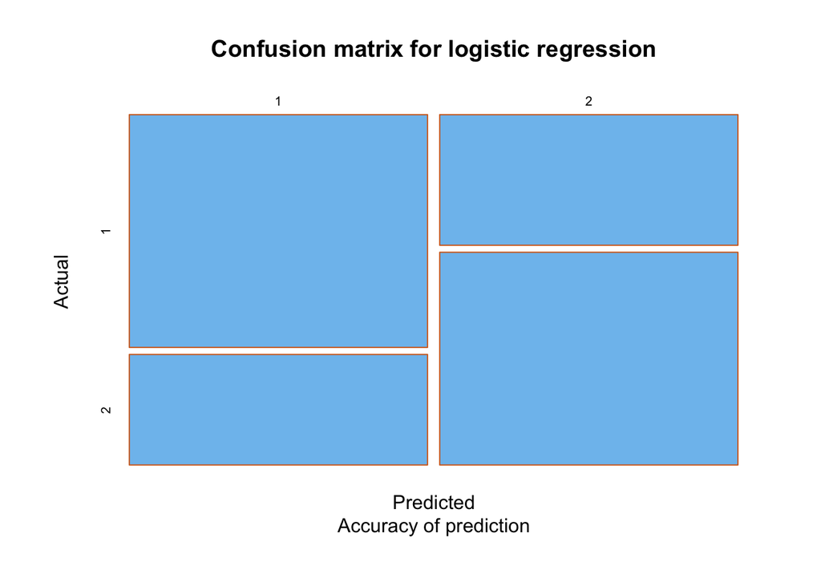

```r
#simple mosaic plot
mosaicplot(mosaic_table,
           main = "Confusion matrix for logistic regression",
           sub = "Accuracy of prediction",
           xlab = "Predicted",
           ylab = "Actual",
           color = "skyblue2",
           border = "chocolate")
```

**Using the mosaic plot, we can visualize the confusion matrix, which leads to similar conclusions that the model is not doing a good job of correctly predicting which WPS group a student belongs to based on early math skills and sustained attention.**

# 6 Discussion